Jasmine Leblond-Chartrand

COMP 499 Final Project Report

# Answering public health questions with National Health Surveys

### A case study of primary hypertension with NHANES 2013-2014

The NHANES (National Health and Nutrition Examination Survey) is a survey conducted across United-States to assess the health and nutritional status of individuals living in that country. The dataset includes extensive information about the participants (i.e. demographics, labs, examinations, and questionnaires)

10,175 people were interviewed in the 2013-2014 edition.

This project consists of a case study in a data exploratory perspective of hypertension, the condition for which medication is the most often prescribed according to the NHANES medications.csv dataset (n = 1595). This is also the most common primary diagnosis in the United States. QUESTIONS Q1: What are the variables associated with hypertension? (correlation) Q2: Can we identify individuals with hypertension? (classification) Q3: What is the age at which people are told they have hypertension? (regression)

## Data Acquisition (via Kaggle API)

```python
# Install the Kaggle API to be allowed download the file

# pip install kaggle
```

```python
# Need to download a kaggle.json file from the user account page on kaggle.com
# put it in ~/.kaggle/kaggle.json
```

```python
import kaggle

# dataset from "https://www.kaggle.com/cdc/national-health-and-nutrition-examination-survey/"

!kaggle datasets download -d cdc/national-health-and-nutrition-examination-survey -p './data/' --unzip

# -p denotes download path
    # download the dataset as a single zip file to './data'
# --unzip
    # extract the files ['demographic.csv', 'diet.csv', 'examination.csv', 'labs.csv', 'medications.csv', 'questionnaire.csv']
```

## Data Profiling and Cleaning

### Step 2: Loading the data

```python
import pandas as pd
import numpy as np


data_demographic = pd.read_csv('./data/demographic.csv', index_col='SEQN', usecols=['SEQN', 'RIAGENDR', 'RIDAGEYR', 'INDHHIN2', 'INDFMIN2'])
# data_diet = pd.read_csv('./data/diet.csv')
# data_examination = pd.read_csv('./data/examination.csv')
# data_labs = pd.read_csv('./data/labs.csv')
data_medications = pd.read_csv('./data/medications.csv',  encoding = "ISO-8859-1", usecols= ['SEQN', 'RXDRSC1', 'RXDRSD1'])
data_questionnaire = pd.read_csv('./data/questionnaire.csv', index_col='SEQN')

data_questionnaire.head(10)
```

| SEQN | ACD011A | ACD011B | ACD011C | ACD040 | ACD110 | ALQ101 | ALQ110 | ALQ120Q | ALQ120U | ALQ130 | ... | WHD080U | WHD080L | WHD110 | WHD120 | WHD130 | WHD140 | WHQ150 | WHQ030M | WHQ500 | WHQ520 |
| --- | --- | --- | --- | --- | --- | --- | --- | --- | --- | --- | --- | --- | --- | --- | --- | --- | --- | --- | --- | --- | --- |
| 73557 | 1.0 | NaN | NaN | NaN | NaN | 1.0 | NaN | 1.0 | 3.0 | 1.0 | ... | NaN | 40.0 | 270.0 | 200.0 | 69.0 | 270.0 | 62.0 | NaN | NaN | NaN |
| 73558 | 1.0 | NaN | NaN | NaN | NaN | 1.0 | NaN | 7.0 | 1.0 | 4.0 | ... | NaN | NaN | 240.0 | 250.0 | 72.0 | 250.0 | 25.0 | NaN | NaN | NaN |
| 73559 | 1.0 | NaN | NaN | NaN | NaN | 1.0 | NaN | 0.0 | NaN | NaN | ... | NaN | NaN | 180.0 | 190.0 | 70.0 | 228.0 | 35.0 | NaN | NaN | NaN |
| 73560 | 1.0 | NaN | NaN | NaN | NaN | NaN | NaN | NaN | NaN | NaN | ... | NaN | NaN | NaN | NaN | NaN | NaN | NaN | 3.0 | 3.0 | 3.0 |
| 73561 | 1.0 | NaN | NaN | NaN | NaN | 1.0 | NaN | 0.0 | NaN | NaN | ... | NaN | NaN | 150.0 | 135.0 | 67.0 | 170.0 | 60.0 | NaN | NaN | NaN |
| 73562 | NaN | NaN | NaN | 4.0 | NaN | 1.0 | NaN | 5.0 | 3.0 | 1.0 | ... | NaN | NaN | 225.0 | 195.0 | 64.0 | 244.0 | 54.0 | NaN | NaN | NaN |
| 73563 | NaN | NaN | NaN | NaN | NaN | NaN | NaN | NaN | NaN | NaN | ... | NaN | NaN | NaN | NaN | NaN | NaN | NaN | NaN | NaN | NaN |
| 73564 | 1.0 | NaN | NaN | NaN | NaN | 2.0 | 1.0 | 2.0 | 3.0 | 1.0 | ... | NaN | NaN | 195.0 | 127.0 | 64.0 | 212.0 | 61.0 | NaN | NaN | NaN |
| 73565 | NaN | NaN | NaN | 5.0 | NaN | NaN | NaN | NaN | NaN | NaN | ... | NaN | NaN | 225.0 | 185.0 | NaN | 235.0 | 37.0 | NaN | NaN | NaN |
| 73566 | 1.0 | NaN | NaN | NaN | NaN | 1.0 | NaN | 1.0 | 1.0 | 1.0 | ... | NaN | NaN | 130.0 | 120.0 | 61.0 | 152.0 | 45.0 | NaN | NaN | NaN |

10 rows × 952 columns

```python
data_medications.iloc[:10]
```

|  | SEQN | RXDRSC1 | RXDRSD1 |
| --- | --- | --- | --- |
| 0 | 73557 | NaN | NaN |
| 1 | 73557 | E11 | Type 2 diabetes mellitus |
| 2 | 73558 | G25.81 | Restless legs syndrome |
| 3 | 73558 | E11 | Type 2 diabetes mellitus |
| 4 | 73558 | E11.2 | Type 2 diabetes mellitus with kidney complicat... |
| 5 | 73558 | E78.0 | Pure hypercholesterolemia |
| 6 | 73559 | E11 | Type 2 diabetes mellitus |
| 7 | 73559 | E11 | Type 2 diabetes mellitus |
| 8 | 73559 | K86.9 | Disease of pancreas, unspecified |
| 9 | 73559 | E78.0 | Pure hypercholesterolemia |

```python
data_questionnaire.describe()

# Note: descriptive analysis on data_questionnaire will be done at a later step, after merging the 2 datasets.
```

|  | ACD011A | ACD011B | ACD011C | ACD040 | ACD110 | ALQ101 | ALQ110 | ALQ120Q | ALQ120U | ALQ130 | ... | WHD080U | WHD080L | WHD110 | WHD120 | WHD130 | WHD140 | WHQ150 | WHQ030M | WHQ500 | WHQ520 |
| --- | --- | --- | --- | --- | --- | --- | --- | --- | --- | --- | --- | --- | --- | --- | --- | --- | --- | --- | --- | --- | --- |
| count | 5759.0 | 16.0 | 171.0 | 2374.000000 | 1007.000000 | 5421.000000 | 1631.000000 | 4479.000000 | 3593.000000 | 3596.000000 | ... | 15.0 | 29.0 | 4179.000000 | 5024.000000 | 2765.000000 | 6103.000000 | 6020.000000 | 1478.000000 | 1478.000000 | 1478.000000 |
| mean | 1.0 | 8.0 | 9.0 | 3.101095 | 2.956306 | 1.311197 | 1.594727 | 4.709310 | 1.921514 | 3.511123 | ... | 35.0 | 40.0 | 412.158411 | 568.528463 | 377.322966 | 315.623464 | 571.309635 | 2.583221 | 2.299729 | 1.746955 |
| std | 0.0 | 0.0 | 0.0 | 1.511821 | 1.733794 | 0.545023 | 0.615303 | 34.428362 | 0.853701 | 28.866122 | ... | 0.0 | 0.0 | 1508.005974 | 1977.085854 | 1726.344740 | 1077.068750 | 7269.067701 | 0.784612 | 1.213281 | 0.709430 |
| min | 1.0 | 8.0 | 9.0 | 1.000000 | 1.000000 | 1.000000 | 1.000000 | 0.000000 | 1.000000 | 1.000000 | ... | 35.0 | 40.0 | 75.000000 | 55.000000 | 50.000000 | 85.000000 | 10.000000 | 1.000000 | 1.000000 | 1.000000 |
| 25% | 1.0 | 8.0 | 9.0 | 2.000000 | 1.000000 | 1.000000 | 1.000000 | 1.000000 | 1.000000 | 1.000000 | ... | 35.0 | 40.0 | 140.000000 | 125.000000 | 63.000000 | 155.000000 | 25.000000 | 3.000000 | 1.000000 | 1.000000 |
| 50% | 1.0 | 8.0 | 9.0 | 3.000000 | 3.000000 | 1.000000 | 2.000000 | 2.000000 | 2.000000 | 2.000000 | ... | 35.0 | 40.0 | 165.000000 | 150.000000 | 66.000000 | 185.000000 | 38.000000 | 3.000000 | 2.000000 | 2.000000 |
| 75% | 1.0 | 8.0 | 9.0 | 4.000000 | 5.000000 | 2.000000 | 2.000000 | 4.000000 | 3.000000 | 3.000000 | ... | 35.0 | 40.0 | 198.000000 | 180.000000 | 70.000000 | 224.000000 | 53.000000 | 3.000000 | 3.000000 | 2.000000 |
| max | 1.0 | 8.0 | 9.0 | 9.000000 | 5.000000 | 9.000000 | 9.000000 | 999.000000 | 3.000000 | 999.000000 | ... | 35.0 | 40.0 | 9999.000000 | 9999.000000 | 9999.000000 | 9999.000000 | 99999.000000 | 9.000000 | 9.000000 | 9.000000 |

8 rows × 950 columns

Descriptive statistical analysis is irrelevant for data_medications, since we are only dealing with 'SEQN', which is the respondant sequence number.

```python
data_medications.describe()
```

|  | SEQN |
| --- | --- |
| count | 20194.000000 |
| mean | 78545.350946 |
| std | 2933.000334 |
| min | 73557.000000 |
| 25% | 75984.250000 |
| 50% | 78506.000000 |
| 75% | 81063.000000 |
| max | 83731.000000 |

#### Defining Questions

```python
pd.set_option('display.max_rows',500)
pd.set_option('display.max_columns',500)


# List of the most frequent medical diagnoses
# Hypertension is the most frequently seen condition in this dataset.
# Therefore, this project will revolve around this topic

patients_conditions = data_medications.drop_duplicates(subset=['SEQN', 'RXDRSC1'], keep='first').copy()

grouped_conditions = patients_conditions.groupby(['RXDRSC1', 'RXDRSD1'])
df_grouped_conditions = grouped_conditions['SEQN'].count().sort_values(ascending=False).head(10)
print(df_grouped_conditions)
```

```
RXDRSC1  RXDRSD1
I10      Essential (primary) hypertension                          1595
E78.0    Pure hypercholesterolemia                                 1101
E11      Type 2 diabetes mellitus                                   575
K21      Gastro-esophageal reflux disease                           434
F32.9    Major depressive disorder, single episode, unspecified     399
J45      Asthma                                                     348
F41.9    Anxiety disorder, unspecified                              346
E03.9    Hypothyroidism, unspecified                                334
M54.9    Dorsalgia, unspecified                                     214
G47.0    Insomnia                                                   198
Name: SEQN, dtype: int64
```

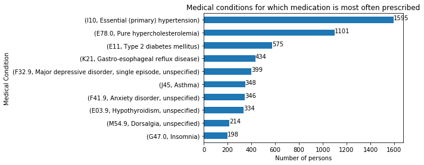

```python
import matplotlib.pyplot as plt
%matplotlib inline


df_grouped_conditions.plot.barh().invert_yaxis()
plt.title('Medical conditions for which medication is most often prescribed')
plt.xlabel('Number of persons', fontsize=10)
plt.ylabel('Medical Condition', fontsize=10)
for index,data in enumerate(df_grouped_conditions):
    plt.text(x=data, y =index , s=f"{data}" , fontdict=dict(fontsize=10))
#plt.show()
import os
outdir = './figs/'
if not os.path.exists(outdir):
    os.mkdir(outdir)

plt.savefig(outdir+'medical_conditions.png', bbox_inches = 'tight')
```

Datasets and indicators that will be used in this project:

data_medications

```
* SEQN: Respondent sequence number
* RXDRSC1:  ICD-10-CM code 1
* RXDRSD1: ICD-10-CM code 1 description
```

data_questionnaire

```
* All indicators
```

### Step 2: Basic Statistics (Profiling)

```python
print ('Number of participants in data_questionnaire: {}'.format(data_questionnaire.shape[0]))
```

```
Number of participants in data_questionnaire: 10175
```

```python
print ('Number of rows in data_medications: {}'.format(data_medications.shape[0]))
```

```
Number of rows in data_medications: 20194
```

```python
print ('Number of variables in data_questionnaire: {}'.format(data_questionnaire.shape[1]))
```

```
Number of variables in data_questionnaire: 952
```

### Step 3: Dealing with duplicates (Cleaning)

#### data_questionnaire

```python
# No duplicate participants in data_questionnaire

nb_duplicates = sum(data_questionnaire.duplicated(keep=False))
print('Number of duplicate participants in data_questionnaire: ' + str(nb_duplicates))
```

```
Number of duplicate participants in data_questionnaire: 0
```

#### data_medications

This is a long-format table with duplicate participant rows, where each rows represents a unique combination of ['SEQN', 'RXDDRUG'] columns (=> a prescribed drug to a patient)

There will certainly be duplicates 'SEQN', or duplicates 'RXDRSC1'(if a patient takes more than one medication for the same diagnosed condition)

```python
print ('Number of rows in data_medications: {}'.format(data_medications.shape[0]))

nb_duplicates = sum(data_medications.duplicated(subset=['SEQN'], keep=False))
print('Number of duplicate participants in data_medications: ' + str(nb_duplicates))
```

```
Number of rows in data_medications: 20194
Number of duplicate participants in data_medications: 12777
```

- We have to filter participants based on hypertension diagnosis (ICD10 code: 'I10')

```python
print ('Number of rows in data_medications: {}'.format(data_medications.shape[0]))

unique_participants = sum(data_medications.duplicated(subset=['SEQN'], keep=False))
print('Number of unique participants in data_medications: ' + str(unique_participants))
```

```
Number of rows in data_medications: 20194
Number of unique participants in data_medications: 12777
```

```python
rows_with_hypertension = data_medications[(data_medications.RXDRSC1=='I10')]

nb_rows_with_hypertension = len(rows_with_hypertension)
print('Number of rows with hypertension in data_medications: ' + str(nb_rows_with_hypertension))


nb_duplicate_patients_hypertension = sum(rows_with_hypertension.duplicated(subset=['SEQN'], keep=False))
print('Number of duplicate patients with hypertension in data_medications: ' + str(nb_duplicate_patients_hypertension))
```

```
Number of rows with hypertension in data_medications: 2421
Number of duplicate patients with hypertension in data_medications: 1431
```

```python
# Remove duplicate patient entries
unique_patients = rows_with_hypertension.drop_duplicates(subset=['SEQN'], keep='first').copy()
# set 'SEQN' as table index
unique_patients = unique_patients.set_index('SEQN')

nb_unique_patients = len(unique_patients)
print('Number of unique patients with hypertension: ' + str(nb_unique_patients))
```

```
Number of unique patients with hypertension: 1595
```

## Data Matching & Merging

```python
data = pd.merge(data_demographic, data_questionnaire, how='outer', left_index=True, right_index=True)
data = pd.merge(unique_patients, data, how='outer', left_index=True, right_index=True)

# Preview of data
data.head(10)
```

| SEQN | RXDRSC1 | RXDRSD1 | RIAGENDR | RIDAGEYR | INDHHIN2 | INDFMIN2 | ACD011A | ACD011B | ACD011C | ACD040 | ACD110 | ALQ101 | ALQ110 | ALQ120Q | ALQ120U | ALQ130 | ALQ141Q | ALQ141U | ALQ151 | ALQ160 | BPQ020 | BPQ030 | BPD035 | BPQ040A | BPQ050A | BPQ056 | BPD058 | BPQ059 | BPQ080 | … |
| --- | --- | --- | --- | --- | --- | --- | --- | --- | --- | --- | --- | --- | --- | --- | --- | --- | --- | --- | --- | --- | --- | --- | --- | --- | --- | --- | --- | --- | --- | --- |
| 73557 | NaN | NaN | 1 | 69 | 4.0 | 4.0 | 1.0 | NaN | NaN | NaN | NaN | 1.0 | NaN | 1.0 | 3.0 | 1.0 | 0.0 | NaN | 1.0 | NaN | 1.0 | 1.0 | 62.0 | 1.0 | 2.0 | 2.0 | NaN | 2.0 | 1.0 | … |
| 73558 | NaN | NaN | 1 | 54 | 7.0 | 7.0 | 1.0 | NaN | NaN | NaN | NaN | 1.0 | NaN | 7.0 | 1.0 | 4.0 | 2.0 | 1.0 | 1.0 | 0.0 | 1.0 | 1.0 | 53.0 | 2.0 | NaN | 1.0 | 52.0 | 2.0 | 1.0 | … |
| 73559 | I10 | Essential (primary) hypertension | 1 | 72 | 10.0 | 10.0 | 1.0 | NaN | NaN | NaN | NaN | 1.0 | NaN | 0.0 | NaN | NaN | NaN | NaN | 2.0 | NaN | 1.0 | 1.0 | 40.0 | 1.0 | 1.0 | 2.0 | NaN | 2.0 | 1.0 | … |
| 73560 | NaN | NaN | 1 | 9 | 9.0 | 9.0 | 1.0 | NaN | NaN | NaN | NaN | NaN | NaN | NaN | NaN | NaN | NaN | NaN | NaN | NaN | NaN | NaN | NaN | NaN | NaN | NaN | NaN | NaN | NaN | … |
| 73561 | I10 | Essential (primary) hypertension | 2 | 73 | 15.0 | 15.0 | 1.0 | NaN | NaN | NaN | NaN | 1.0 | NaN | 0.0 | NaN | NaN | NaN | NaN | 2.0 | NaN | 1.0 | 2.0 | 55.0 | 1.0 | 1.0 | 1.0 | 12.0 | 2.0 | 2.0 | … |
| 73562 | I10 | Essential (primary) hypertension | 1 | 56 | 9.0 | 9.0 | NaN | NaN | NaN | 4.0 | NaN | 1.0 | NaN | 5.0 | 3.0 | 1.0 | 0.0 | NaN | 2.0 | 0.0 | 1.0 | 1.0 | 35.0 | 1.0 | 1.0 | 1.0 | 365.0 | 1.0 | 1.0 | … |
| 73563 | NaN | NaN | 1 | 0 | 15.0 | 15.0 | NaN | NaN | NaN | NaN | NaN | NaN | NaN | NaN | NaN | NaN | NaN | NaN | NaN | NaN | NaN | NaN | NaN | NaN | NaN | NaN | NaN | NaN | NaN | … |
| 73564 | NaN | NaN | 2 | 61 | 10.0 | 10.0 | 1.0 | NaN | NaN | NaN | NaN | 2.0 | 1.0 | 2.0 | 3.0 | 1.0 | 0.0 | NaN | 2.0 | NaN | 1.0 | 1.0 | 47.0 | 1.0 | 2.0 | 2.0 | NaN | 2.0 | 2.0 | … |
| 73565 | NaN | NaN | 1 | 42 | 15.0 | 15.0 | NaN | NaN | NaN | 5.0 | NaN | NaN | NaN | NaN | NaN | NaN | NaN | NaN | NaN | NaN | 2.0 | NaN | NaN | NaN | NaN | 2.0 | NaN | 2.0 | 2.0 | … |
| 73566 | NaN | NaN | 2 | 56 | 4.0 | 4.0 | 1.0 | NaN | NaN | NaN | NaN | 1.0 | NaN | 1.0 | 1.0 | 1.0 | 0.0 | NaN | 2.0 | NaN | 2.0 | NaN | NaN | NaN | NaN | 2.0 | NaN | 2.0 | 2.0 | … |

10 rows × 958 columns

### Basic Stats

```python
rows_count = data.shape[0] # Number of rows

columns_count = data.shape[1] # Number of columns

rows_count
```

```
10175
```

### Cleaning

There are no rows with all NaN column values.

```python
# Drops rows where all column values are NaN
data.dropna(axis=0, how='all')
data.shape
```

```
(10175, 958)
```

#### Replacing missing values

```python
dont_know_values = [99.0, 999.0]
refused_to_answer_values = [77.0, 777.0]

values_to_replace = dont_know_values + refused_to_answer_values

for value in values_to_replace:
    data.replace(float(value), np.nan, inplace=True)

data.replace('', np.nan, inplace=True)

data.head(10)
```

| SEQN | RXDRSC1 | RXDRSD1 | RIAGENDR | RIDAGEYR | INDHHIN2 | INDFMIN2 | ACD011A | ACD011B | ACD011C | ACD040 | ACD110 | ALQ101 | ALQ110 | ALQ120Q | ALQ120U | ALQ130 | ALQ141Q | ALQ141U | ALQ151 | ALQ160 | BPQ020 | BPQ030 | BPD035 | BPQ040A | BPQ050A | BPQ056 | BPD058 | BPQ059 | BPQ080 | … |
| --- | --- | --- | --- | --- | --- | --- | --- | --- | --- | --- | --- | --- | --- | --- | --- | --- | --- | --- | --- | --- | --- | --- | --- | --- | --- | --- | --- | --- | --- | --- |
| 73557 | NaN | NaN | 1 | 69.0 | 4.0 | 4.0 | 1.0 | NaN | NaN | NaN | NaN | 1.0 | NaN | 1.0 | 3.0 | 1.0 | 0.0 | NaN | 1.0 | NaN | 1.0 | 1.0 | 62.0 | 1.0 | 2.0 | 2.0 | NaN | 2.0 | 1.0 | … |
| 73558 | NaN | NaN | 1 | 54.0 | 7.0 | 7.0 | 1.0 | NaN | NaN | NaN | NaN | 1.0 | NaN | 7.0 | 1.0 | 4.0 | 2.0 | 1.0 | 1.0 | 0.0 | 1.0 | 1.0 | 53.0 | 2.0 | NaN | 1.0 | 52.0 | 2.0 | 1.0 | … |
| 73559 | I10 | Essential (primary) hypertension | 1 | 72.0 | 10.0 | 10.0 | 1.0 | NaN | NaN | NaN | NaN | 1.0 | NaN | 0.0 | NaN | NaN | NaN | NaN | 2.0 | NaN | 1.0 | 1.0 | 40.0 | 1.0 | 1.0 | 2.0 | NaN | 2.0 | 1.0 | … |
| 73560 | NaN | NaN | 1 | 9.0 | 9.0 | 9.0 | 1.0 | NaN | NaN | NaN | NaN | NaN | NaN | NaN | NaN | NaN | NaN | NaN | NaN | NaN | NaN | NaN | NaN | NaN | NaN | NaN | NaN | NaN | NaN | … |
| 73561 | I10 | Essential (primary) hypertension | 2 | 73.0 | 15.0 | 15.0 | 1.0 | NaN | NaN | NaN | NaN | 1.0 | NaN | 0.0 | NaN | NaN | NaN | NaN | 2.0 | NaN | 1.0 | 2.0 | 55.0 | 1.0 | 1.0 | 1.0 | 12.0 | 2.0 | 2.0 | … |
| 73562 | I10 | Essential (primary) hypertension | 1 | 56.0 | 9.0 | 9.0 | NaN | NaN | NaN | 4.0 | NaN | 1.0 | NaN | 5.0 | 3.0 | 1.0 | 0.0 | NaN | 2.0 | 0.0 | 1.0 | 1.0 | 35.0 | 1.0 | 1.0 | 1.0 | 365.0 | 1.0 | 1.0 | … |
| 73563 | NaN | NaN | 1 | 0.0 | 15.0 | 15.0 | NaN | NaN | NaN | NaN | NaN | NaN | NaN | NaN | NaN | NaN | NaN | NaN | NaN | NaN | NaN | NaN | NaN | NaN | NaN | NaN | NaN | NaN | NaN | … |
| 73564 | NaN | NaN | 2 | 61.0 | 10.0 | 10.0 | 1.0 | NaN | NaN | NaN | NaN | 2.0 | 1.0 | 2.0 | 3.0 | 1.0 | 0.0 | NaN | 2.0 | NaN | 1.0 | 1.0 | 47.0 | 1.0 | 2.0 | 2.0 | NaN | 2.0 | 2.0 | … |
| 73565 | NaN | NaN | 1 | 42.0 | 15.0 | 15.0 | NaN | NaN | NaN | 5.0 | NaN | NaN | NaN | NaN | NaN | NaN | NaN | NaN | NaN | NaN | 2.0 | NaN | NaN | NaN | NaN | 2.0 | NaN | 2.0 | 2.0 | … |
| 73566 | NaN | NaN | 2 | 56.0 | 4.0 | 4.0 | 1.0 | NaN | NaN | NaN | NaN | 1.0 | NaN | 1.0 | 1.0 | 1.0 | 0.0 | NaN | 2.0 | NaN | 2.0 | NaN | NaN | NaN | NaN | 2.0 | NaN | 2.0 | 2.0 | … |

10 rows × 958 columns

For each column containing 7.0/9.0 numeric values, we need to verify whether we have continuous values (i.e. age, quantity) or categorical values (i.e. 'refused' or 'don't know' value)

```python
arr_values_to_check = [7.0, 9.0]

for value in arr_values_to_check:
    print('Indexes where value = '+str(value))
    print(data.columns[(data == value).iloc[0]])
```

```
Indexes where value = 7.0
Index(['DUQ240', 'SLD010H', 'SMD480'], dtype='object')
Indexes where value = 9.0
Index(['INQ244', 'MCQ195', 'OSQ200'], dtype='object')
```

##### DUQ240 - Ever used cocaine/heroin/methamphetamine

Description: Have you ever used cocaine, crack cocaine, heroin, or methamphetamine?

| Code or Value | Value Description | Count | Cumulative | Skip to Item |
| --- | --- | --- | --- | --- |
| 1 | Yes | 723 | 723 |  |
| 2 | No | 3800 | 4523 | DUQ370 |
| 7 | Refused | 10 | 4533 | DUQ370 |
| 9 | Don't know | 7 | 4540 | DUQ370 |
| . | Missing | 517 | 5057 |  |

##### SLD010H - How much sleep do you get (hours)?

Description: The next set of questions is about your sleeping habits. How much sleep )do you/does SP) usually get at night on weekdays or workdays?

| Code or Value | Value Description | Count | Cumulative | Skip to Item |
| --- | --- | --- | --- | --- |
| 2 to 11 | Range of Values | 6835 | 6835 |  |
| 12 | 12 hours or more | 39 | 6874 |  |
| 77 | Refused | 0 | 6874 |  |
| 99 | Don't know | 8 | 6882 |  |
| . | Missing | 7 | 6889 |  |

##### SMD480 - In past week # days person smoked inside

Description: (Not counting decks, porches, or detached garages) During the past 7 days, that is since last [TODAY'S DAY OF WEEK], on how many days did {anyone who lives here/you}, smoke tobacco inside this home?

Instructions: ENTER NUMBER OF DAYS FROM 0 TO 7. CAPI INSTRUCTION: IF ONLY ONE PERSON LIVING IN HOUSEHOLD DISPLAY "you.." IF MORE THAN ONE PERSON LIVING IN HOUSEHOLD, DISPLAY "anyone who lives here.."

| Code or Value | Value Description | Count | Cumulative | Skip to Item |
| --- | --- | --- | --- | --- |
| 0 | 0 | 98 | 98 |  |
| 1 | 1 | 179 | 277 |  |
| 2 | 2 | 230 | 507 |  |
| 3 | 3 | 49 | 556 |  |
| 4 | 4 | 35 | 591 |  |
| 5 | 5 | 27 | 618 |  |
| 6 | 6 | 7 | 625 |  |
| 7 | 7 | 679 | 1304 |  |
| 77 | Refused | 0 | 1304 |  |
| 99 | Don't know | 3 | 1307 |  |
| . | Missing | 8868 | 10175 |  |

##### INQ244 - Family has savings more than $5000

Description: Do you/NAMES OF OTHER FAMILY/you and NAMES OF FAMILY MEMBERS have more than $5,000 in savings at this time? Please include money in your checking accounts.

| Code or Value | Value Description | Count | Cumulative | Skip to Item |
| --- | --- | --- | --- | --- |
| 1 | Yes | 449 | 449 | End of Section |
| 2 | No | 4803 | 5252 |  |
| 7 | Refused | 107 | 5359 | End of Section |
| 9 | Don't know | 141 | 5500 | End of Section |
| . | Missing | 4256 | 9756 |  |

##### MCQ195 - Which type of arthritis was it?

Description: Which type of arthritis was it?

| Code or Value | Value Description | Count | Cumulative | Skip to Item |
| --- | --- | --- | --- | --- |
| 1 | Osteoarthritis or degenerative arthritis | 576 | 576 |  |
| 2 | Rheumatoid arthritis | 249 | 825 |  |
| 3 | Psoriatic arthritis | 17 | 842 |  |
| 4 | Other | 104 | 946 |  |
| 7 | Refused | 0 | 946 |  |
| 9 | Don't know | 419 | 1365 |  |
| . | Missing | 7999 | 9364 |  |

##### OSQ200 - Did father ever fracture hip?

Description: Did (your/SP's) biological father ever fracture his hip?

| Code or Value | Value Description | Count | Cumulative | Skip to Item |
| --- | --- | --- | --- | --- |
| 1 | Yes | 109 | 109 |  |
| 2 | No | 5766 | 5875 |  |
| 7 | Refused | 4 | 5879 |  |
| 9 | Don't know | 339 | 6218 |  |
| . | Missing | 0 | 6218 |  |

Conclusion:

Categorical columns (where 7.0 or 9.0 represents 'refused' or 'don't know'): DUQ240, INQ244, MCQ195, OSQ200

```python
columns = ['DUQ240', 'INQ244', 'MCQ195', 'OSQ200', 'BPQ020']
values_to_replace = [7.0, 9.0]

for value in values_to_replace:
    data[columns] = data[columns].replace(float(value), np.nan, inplace=False)


data[columns].head(10)
```

| SEQN | DUQ240 | INQ244 | MCQ195 | OSQ200 | BPQ020 |
| --- | --- | --- | --- | --- | --- |
| 73557 | NaN | NaN | NaN | NaN | 1.0 |
| 73558 | 1.0 | 1.0 | NaN | 2.0 | 1.0 |
| 73559 | NaN | NaN | NaN | 2.0 | 1.0 |
| 73560 | NaN | NaN | NaN | NaN | NaN |
| 73561 | NaN | NaN | NaN | 2.0 | 1.0 |
| 73562 | 2.0 | NaN | 2.0 | 2.0 | 1.0 |
| 73563 | NaN | NaN | NaN | NaN | NaN |
| 73564 | 2.0 | NaN | 2.0 | 2.0 | 1.0 |
| 73565 | NaN | NaN | NaN | 2.0 | 2.0 |
| 73566 | 2.0 | 2.0 | 2.0 | 2.0 | 2.0 |

### Replace hypertension condition strings to bool (0.0 or 1.0)

```python
hypertension_values = ['I10', 'Essential (primary) hypertension']
# Replace all values 'I10' or 'Essential (primary) hypertension' with 1.0
for value in hypertension_values:
    data.replace(value, 1, inplace=True)

# Replace all values NaN in these columns with 0.0
data['RXDRSC1'].replace(np.nan, 0, inplace=True)
data['RXDRSD1'].replace(np.nan, 0, inplace=True)

data.head(5)
```

| SEQN | RXDRSC1 | RXDRSD1 | RIAGENDR | RIDAGEYR | INDHHIN2 | INDFMIN2 | ACD011A | ACD011B | ACD011C | ACD040 | ACD110 | ALQ101 | ALQ110 | ALQ120Q | ALQ120U | ALQ130 | ALQ141Q | ALQ141U | ALQ151 | ALQ160 | BPQ020 | BPQ030 | BPD035 | BPQ040A | BPQ050A | BPQ056 | BPD058 | BPQ059 | BPQ080 | … |
| --- | --- | --- | --- | --- | --- | --- | --- | --- | --- | --- | --- | --- | --- | --- | --- | --- | --- | --- | --- | --- | --- | --- | --- | --- | --- | --- | --- | --- | --- | --- |
| 73557 | 0.0 | 0.0 | 1 | 69.0 | 4.0 | 4.0 | 1.0 | NaN | NaN | NaN | NaN | 1.0 | NaN | 1.0 | 3.0 | 1.0 | 0.0 | NaN | 1.0 | NaN | 1.0 | 1.0 | 62.0 | 1.0 | 2.0 | 2.0 | NaN | 2.0 | 1.0 | … |
| 73558 | 0.0 | 0.0 | 1 | 54.0 | 7.0 | 7.0 | 1.0 | NaN | NaN | NaN | NaN | 1.0 | NaN | 7.0 | 1.0 | 4.0 | 2.0 | 1.0 | 1.0 | 0.0 | 1.0 | 1.0 | 53.0 | 2.0 | NaN | 1.0 | 52.0 | 2.0 | 1.0 | … |
| 73559 | 1.0 | 1.0 | 1 | 72.0 | 10.0 | 10.0 | 1.0 | NaN | NaN | NaN | NaN | 1.0 | NaN | 0.0 | NaN | NaN | NaN | NaN | 2.0 | NaN | 1.0 | 1.0 | 40.0 | 1.0 | 1.0 | 2.0 | NaN | 2.0 | 1.0 | … |
| 73560 | 0.0 | 0.0 | 1 | 9.0 | 9.0 | 9.0 | 1.0 | NaN | NaN | NaN | NaN | NaN | NaN | NaN | NaN | NaN | NaN | NaN | NaN | NaN | NaN | NaN | NaN | NaN | NaN | NaN | NaN | NaN | NaN | … |
| 73561 | 1.0 | 1.0 | 2 | 73.0 | 15.0 | 15.0 | 1.0 | NaN | NaN | NaN | NaN | 1.0 | NaN | 0.0 | NaN | NaN | NaN | NaN | 2.0 | NaN | 1.0 | 2.0 | 55.0 | 1.0 | 1.0 | 1.0 | 12.0 | 2.0 | 2.0 | … |

5 rows × 958 columns

#### Removing columns with string dtype

```python
df_subset = data.select_dtypes(exclude=[np.number])

# SMDUPCA - Cig 12-digit Universal Product Code-UPC
# Description: Cigarette 12-digit Universal Product Code (UPC)
# Link: https://wwwn.cdc.gov/Nchs/Nhanes/2013-2014/SMQ_H.htm#SMDUPCA
data['SMDUPCA']

# SMD100BR - Cigarette Brand/sub-brand
# Description: BRAND OF CIGARETTES SMOKED BY SP (SUB-BRAND INCLUDED IF APPLICABLE AND AVAILABLE)
# Link: https://wwwn.cdc.gov/Nchs/Nhanes/2013-2014/SMQ_H.htm#SMD100BR
data['SMD100BR']


data = data.drop('SMDUPCA', axis=1)
data = data.drop('SMD100BR', axis=1)
```

### Descriptive Analysis

The count, for each column, denotes how many patients have answered this column.

There are many columns for which the number of patients (n) is too small to draw conclusions.

```python
data.describe()
```

|  | RXDRSC1 | RXDRSD1 | RIAGENDR | RIDAGEYR | INDHHIN2 | INDFMIN2 | ACD011A | ACD011B | ACD011C | ACD040 | ACD110 | ALQ101 | ALQ110 | ALQ120Q | ALQ120U | ALQ130 | ALQ141Q | ALQ141U | ALQ151 | ALQ160 | BPQ020 | BPQ030 | BPD035 | BPQ040A | BPQ050A | BPQ056 | BPD058 | BPQ059 | BPQ080 | … |
| --- | --- | --- | --- | --- | --- | --- | --- | --- | --- | --- | --- | --- | --- | --- | --- | --- | --- | --- | --- | --- | --- | --- | --- | --- | --- | --- | --- | --- | --- | --- |
| count | 10175.000000 | 10175.000000 | 10175.000000 | 10137.000000 | 9715.000000 | 9738.000000 | 5759.0 | 16.0 | 171.0 | 2374.000000 | 1007.000000 | 5421.000000 | 1631.000000 | 4475.000000 | 3593.000000 | 3593.000000 | 3588.000000 | 1464.000000 | 4477.000000 | 1865.000000 | 6459.000000 | 2174.000000 | 2127.000000 | 2174.000000 | 1815.000000 | 6464.000000 | 1579.000000 | 6464.000000 | 6464.000000 | … |
| mean | 0.156757 | 0.156757 | 1.508305 | 31.313505 | 8.489758 | 8.208256 | 1.0 | 8.0 | 9.0 | 3.101095 | 2.956306 | 1.311197 | 1.594727 | 3.820559 | 1.921514 | 2.679933 | 2.124861 | 2.326503 | 1.837168 | 0.689544 | 1.663415 | 1.226311 | 46.063470 | 1.171573 | 1.130028 | 1.757890 | 150.069031 | 1.867420 | 1.723855 | … |
| std | 0.363589 | 0.363589 | 0.499956 | 24.307553 | 4.475009 | 4.523212 | 0.0 | 0.0 | 0.0 | 1.511821 | 1.733794 | 0.545023 | 0.615303 | 17.369714 | 0.853701 | 2.363649 | 11.428595 | 0.844722 | 0.385823 | 2.414553 | 0.472578 | 0.617529 | 15.603121 | 0.440162 | 0.379544 | 0.448164 | 599.215646 | 0.345923 | 0.715436 | … |
| min | 0.000000 | 0.000000 | 1.000000 | 0.000000 | 1.000000 | 1.000000 | 1.0 | 8.0 | 9.0 | 1.000000 | 1.000000 | 1.000000 | 1.000000 | 0.000000 | 1.000000 | 1.000000 | 0.000000 | 1.000000 | 1.000000 | 0.000000 | 1.000000 | 1.000000 | 10.000000 | 1.000000 | 1.000000 | 1.000000 | 1.000000 | 1.000000 | 1.000000 | … |
| 25% | 0.000000 | 0.000000 | 1.000000 | 10.000000 | 5.000000 | 5.000000 | 1.0 | 8.0 | 9.0 | 2.000000 | 1.000000 | 1.000000 | 1.000000 | 1.000000 | 1.000000 | 1.000000 | 0.000000 | 2.000000 | 2.000000 | 0.000000 | 1.000000 | 1.000000 | 35.000000 | 1.000000 | 1.000000 | 2.000000 | 4.000000 | 2.000000 | 1.000000 | … |
| 50% | 0.000000 | 0.000000 | 2.000000 | 26.000000 | 7.000000 | 7.000000 | 1.0 | 8.0 | 9.0 | 3.000000 | 3.000000 | 1.000000 | 2.000000 | 2.000000 | 2.000000 | 2.000000 | 0.000000 | 3.000000 | 2.000000 | 0.000000 | 2.000000 | 1.000000 | 46.000000 | 1.000000 | 1.000000 | 2.000000 | 24.000000 | 2.000000 | 2.000000 | … |
| 75% | 0.000000 | 0.000000 | 2.000000 | 52.000000 | 14.000000 | 14.000000 | 1.0 | 8.0 | 9.0 | 4.000000 | 5.000000 | 2.000000 | 2.000000 | 4.000000 | 3.000000 | 3.000000 | 2.000000 | 3.000000 | 2.000000 | 0.000000 | 2.000000 | 1.000000 | 57.000000 | 1.000000 | 1.000000 | 2.000000 | 104.000000 | 2.000000 | 2.000000 | … |
| max | 1.000000 | 1.000000 | 2.000000 | 80.000000 | 15.000000 | 15.000000 | 1.0 | 8.0 | 9.0 | 9.000000 | 5.000000 | 9.000000 | 9.000000 | 365.000000 | 3.000000 | 25.000000 | 350.000000 | 3.000000 | 9.000000 | 30.000000 | 2.000000 | 9.000000 | 80.000000 | 9.000000 | 9.000000 | 9.000000 | 9999.000000 | 7.000000 | 9.000000 | … |

8 rows × 956 columns

#### Deleting columns where std() = 0

Those columns are removed to simplify the analysis of the datasets. These are often variables split into multiple components. i.e. 'ACD011A' (Speak English at home) 1 or NaN 'ACD011B' (Speak Spanish at home) 8 or NaN 'ACD011C' (Speak other language at home) 9 or NaN

```python
arr_columns_to_remove = data.std()[data.std() == 0.0].index.values
print('Columns to remove (std() = 0): ')
print(arr_columns_to_remove)

print('The number of attributes went')
print('from ' + str(columns_count))
data = data.drop(arr_columns_to_remove, axis=1)
print('to ' + str(data.shape[1]))
```

```
Columns to remove (std() = 0):
['ACD011A' 'ACD011B' 'ACD011C' 'CSQ120A' 'CSQ120B' 'CSQ120C' 'CSQ120D'
 'CSQ120E' 'CSQ120F' 'CSQ120G' 'CSQ120H' 'CDQ009A' 'CDQ009B' 'CDQ009C'
 'CDQ009D' 'CDQ009E' 'CDQ009F' 'CDQ009G' 'CDQ009H' 'DIQ175A' 'DIQ175B'
 'DIQ175C' 'DIQ175D' 'DIQ175E' 'DIQ175F' 'DIQ175G' 'DIQ175H' 'DIQ175I'
 'DIQ175J' 'DIQ175K' 'DIQ175L' 'DIQ175M' 'DIQ175N' 'DIQ175O' 'DIQ175P'
 'DIQ175Q' 'DIQ175R' 'DIQ175S' 'DIQ175T' 'DIQ175U' 'DIQ175V' 'DIQ175W'
 'DIQ175X' 'DBQ073A' 'DBQ073B' 'DBQ073C' 'DBQ073D' 'DBQ073E' 'DBQ073U'
 'DBQ223A' 'DBQ223B' 'DBQ223C' 'DBQ223D' 'DBQ223E' 'DBQ223U' 'DUQ380B'
 'DUQ380C' 'DUQ380D' 'DUQ380E' 'HIQ031A' 'HIQ031B' 'HIQ031C' 'HIQ031D'
 'HIQ031E' 'HIQ031F' 'HIQ031G' 'HIQ031H' 'HIQ031I' 'HIQ031J' 'HIQ031AA'
 'MCQ230D' 'OHQ780A' 'OHQ780B' 'OHQ780C' 'OHQ780D' 'OHQ780E' 'OHQ780F'
 'OHQ780G' 'OHQ780H' 'OHQ780I' 'OHQ780J' 'OHQ780K' 'OSQ040AC' 'OSQ040BE'
 'OSQ040BF' 'OSQ040CC' 'OSQ090F' 'OSQ090H' 'OSQ120H' 'OSQ160A' 'OSQ160B'
 'PAQ724A' 'PAQ724B' 'PAQ724C' 'PAQ724D' 'PAQ724E' 'PAQ724F' 'PAQ724G'
 'PAQ724H' 'PAQ724I' 'PAQ724J' 'PAQ724K' 'PAQ724L' 'PAQ724M' 'PAQ724N'
 'PAQ724O' 'PAQ724P' 'PAQ724Q' 'PAQ724R' 'PAQ724S' 'PAQ724T' 'PAQ724U'
 'PAQ724V' 'PAQ724W' 'PAQ724X' 'PAQ724Y' 'PAQ724Z' 'PAQ724AA' 'PAQ724AB'
 'PAQ724AC' 'PAQ724AD' 'PAQ724AE' 'PAQ724AF' 'PAQ724CM' 'PAQ759A'
 'PAQ759B' 'PAQ759C' 'PAQ759D' 'PAQ759E' 'PAQ759F' 'PAQ759G' 'PAQ759H'
 'PAQ759I' 'PAQ759J' 'PAQ759K' 'PAQ759L' 'PAQ759M' 'PAQ759N' 'PAQ759O'
 'PAQ759P' 'PAQ759Q' 'PAQ759R' 'PAQ759S' 'PAQ759U' 'PAQ759V' 'PAQ772B'
 'PAQ772C' 'RHQ542A' 'RHQ542B' 'RHQ542C' 'RHQ542D' 'SMQ665C' 'SMQ690A'
 'SMQ690B' 'SMQ690C' 'SMQ690G' 'SMQ690H' 'SMQ690D' 'SMQ690E' 'SMQ690I'
 'SMQ690F' 'WHD080A' 'WHD080B' 'WHD080C' 'WHD080D' 'WHD080E' 'WHD080F'
 'WHD080G' 'WHD080H' 'WHD080I' 'WHD080J' 'WHD080K' 'WHD080M' 'WHD080N'
 'WHD080O' 'WHD080P' 'WHD080Q' 'WHD080R' 'WHD080S' 'WHD080T' 'WHD080U'
 'WHD080L']
The number of attributes went
from 958
to 774
```

##### Count

STATISTICAL SIGNIFICANCE

```python
nb_samples_required = 310
# based on
# https://select-statistics.co.uk/calculators/sample-size-calculator-population-proportion/
# confidence=0.95, n=1595

print('The number of attributes went')
print('from ' + str(columns_count))
data = data.loc[:, data.count() >= nb_samples_required]

print('to ' + str(data.shape[1]))
```

```
The number of attributes went
from 958
to 571
```

```python
# Preview of data table with only statistically significant columns
data.head(10)
```

| SEQN | RXDRSC1 | RXDRSD1 | RIAGENDR | RIDAGEYR | INDHHIN2 | INDFMIN2 | ACD040 | ACD110 | ALQ101 | ALQ110 | ALQ120Q | ALQ120U | ALQ130 | ALQ141Q | ALQ141U | ALQ151 | ALQ160 | BPQ020 | BPQ030 | BPD035 | BPQ040A | BPQ050A | BPQ056 | BPD058 | BPQ059 | BPQ080 | BPQ060 | BPQ070 | BPQ090D | … |
| --- | --- | --- | --- | --- | --- | --- | --- | --- | --- | --- | --- | --- | --- | --- | --- | --- | --- | --- | --- | --- | --- | --- | --- | --- | --- | --- | --- | --- | --- | --- |
| 73557 | 0.0 | 0.0 | 1 | 69.0 | 4.0 | 4.0 | NaN | NaN | 1.0 | NaN | 1.0 | 3.0 | 1.0 | 0.0 | NaN | 1.0 | NaN | 1.0 | 1.0 | 62.0 | 1.0 | 2.0 | 2.0 | NaN | 2.0 | 1.0 | NaN | 1.0 | 1.0 | … |
| 73558 | 0.0 | 0.0 | 1 | 54.0 | 7.0 | 7.0 | NaN | NaN | 1.0 | NaN | 7.0 | 1.0 | 4.0 | 2.0 | 1.0 | 1.0 | 0.0 | 1.0 | 1.0 | 53.0 | 2.0 | NaN | 1.0 | 52.0 | 2.0 | 1.0 | NaN | 1.0 | 1.0 | … |
| 73559 | 1.0 | 1.0 | 1 | 72.0 | 10.0 | 10.0 | NaN | NaN | 1.0 | NaN | 0.0 | NaN | NaN | NaN | NaN | 2.0 | NaN | 1.0 | 1.0 | 40.0 | 1.0 | 1.0 | 2.0 | NaN | 2.0 | 1.0 | NaN | 1.0 | 1.0 | … |
| 73560 | 0.0 | 0.0 | 1 | 9.0 | 9.0 | 9.0 | NaN | NaN | NaN | NaN | NaN | NaN | NaN | NaN | NaN | NaN | NaN | NaN | NaN | NaN | NaN | NaN | NaN | NaN | NaN | NaN | NaN | NaN | NaN | … |
| 73561 | 1.0 | 1.0 | 2 | 73.0 | 15.0 | 15.0 | NaN | NaN | 1.0 | NaN | 0.0 | NaN | NaN | NaN | NaN | 2.0 | NaN | 1.0 | 2.0 | 55.0 | 1.0 | 1.0 | 1.0 | 12.0 | 2.0 | 2.0 | 1.0 | 1.0 | 2.0 | … |
| 73562 | 1.0 | 1.0 | 1 | 56.0 | 9.0 | 9.0 | 4.0 | NaN | 1.0 | NaN | 5.0 | 3.0 | 1.0 | 0.0 | NaN | 2.0 | 0.0 | 1.0 | 1.0 | 35.0 | 1.0 | 1.0 | 1.0 | 365.0 | 1.0 | 1.0 | NaN | 2.0 | 1.0 | … |
| 73563 | 0.0 | 0.0 | 1 | 0.0 | 15.0 | 15.0 | NaN | NaN | NaN | NaN | NaN | NaN | NaN | NaN | NaN | NaN | NaN | NaN | NaN | NaN | NaN | NaN | NaN | NaN | NaN | NaN | NaN | NaN | NaN | … |
| 73564 | 0.0 | 0.0 | 2 | 61.0 | 10.0 | 10.0 | NaN | NaN | 2.0 | 1.0 | 2.0 | 3.0 | 1.0 | 0.0 | NaN | 2.0 | NaN | 1.0 | 1.0 | 47.0 | 1.0 | 2.0 | 2.0 | NaN | 2.0 | 2.0 | 1.0 | 2.0 | 2.0 | … |
| 73565 | 0.0 | 0.0 | 1 | 42.0 | 15.0 | 15.0 | 5.0 | NaN | NaN | NaN | NaN | NaN | NaN | NaN | NaN | NaN | NaN | 2.0 | NaN | NaN | NaN | NaN | 2.0 | NaN | 2.0 | 2.0 | 1.0 | 3.0 | 2.0 | … |
| 73566 | 0.0 | 0.0 | 2 | 56.0 | 4.0 | 4.0 | NaN | NaN | 1.0 | NaN | 1.0 | 1.0 | 1.0 | 0.0 | NaN | 2.0 | NaN | 2.0 | NaN | NaN | NaN | NaN | 2.0 | NaN | 2.0 | 2.0 | 1.0 | 2.0 | 2.0 | … |

10 rows × 571 columns

## Exploratory Data Analysis

### Correlation

```python
corr = data.corr()
# corr
```

```python
df = data.loc[:, abs(data.corr()['RXDRSC1']) > 0.2]
df.head()
```

| SEQN | RXDRSC1 | RXDRSD1 | RIDAGEYR | BPQ020 | BPD035 | BPQ040A | BPQ050A | BPQ056 | BPQ059 | BPQ080 | BPQ070 | BPQ090D | HSD010 | HSAQUEX | DIQ010 | DLQ050 | HUQ010 | HUQ051 | IMQ090 | INQ030 | INQ080 | MCQ160A | MCQ365A | MCQ365B | MCQ365C | MCQ365D | MCQ370C | OCD150 | PFQ051 | … |
| --- | --- | --- | --- | --- | --- | --- | --- | --- | --- | --- | --- | --- | --- | --- | --- | --- | --- | --- | --- | --- | --- | --- | --- | --- | --- | --- | --- | --- | --- | --- |
| 73557 | 0.0 | 0.0 | 69.0 | 1.0 | 62.0 | 1.0 | 2.0 | 2.0 | 2.0 | 1.0 | 1.0 | 1.0 | 2.0 | 2.0 | 1.0 | 2.0 | 2 | 5.0 | NaN | 1.0 | 2.0 | 1.0 | 1.0 | 2.0 | 1.0 | 1.0 | 1.0 | 4.0 | 2.0 | … |
| 73558 | 0.0 | 0.0 | 54.0 | 1.0 | 53.0 | 2.0 | NaN | 1.0 | 2.0 | 1.0 | 1.0 | 1.0 | 4.0 | 2.0 | 1.0 | 2.0 | 4 | 5.0 | NaN | 1.0 | 2.0 | 2.0 | 2.0 | 2.0 | 2.0 | 2.0 | 2.0 | 1.0 | 2.0 | … |
| 73559 | 1.0 | 1.0 | 72.0 | 1.0 | 40.0 | 1.0 | 1.0 | 2.0 | 2.0 | 1.0 | 1.0 | 1.0 | 3.0 | 2.0 | 1.0 | 2.0 | 3 | 2.0 | NaN | 1.0 | 1.0 | 2.0 | 2.0 | 2.0 | 2.0 | 2.0 | 2.0 | 4.0 | 2.0 | … |
| 73560 | 0.0 | 0.0 | 9.0 | NaN | NaN | NaN | NaN | NaN | NaN | NaN | NaN | NaN | NaN | 1.0 | 2.0 | 2.0 | 2 | 1.0 | NaN | 2.0 | 2.0 | NaN | NaN | NaN | NaN | NaN | NaN | NaN | NaN | … |
| 73561 | 1.0 | 1.0 | 73.0 | 1.0 | 55.0 | 1.0 | 1.0 | 1.0 | 2.0 | 2.0 | 1.0 | 2.0 | 5.0 | 2.0 | 2.0 | 2.0 | 5 | 4.0 | NaN | 1.0 | 2.0 | 1.0 | 2.0 | 1.0 | 2.0 | 2.0 | 2.0 | 4.0 | 1.0 | … |

```python
df.info()
```

```
<class 'pandas.core.frame.DataFrame'>
Int64Index: 10175 entries, 73557 to 83731
Data columns (total 39 columns):
RXDRSC1      10175 non-null float64
RXDRSD1      10175 non-null float64
RIDAGEYR     10137 non-null float64
BPQ020       6459 non-null float64
BPD035       2127 non-null float64
BPQ040A      2174 non-null float64
BPQ050A      1815 non-null float64
BPQ056       6464 non-null float64
BPQ059       6464 non-null float64
BPQ080       6464 non-null float64
BPQ070       4620 non-null float64
BPQ090D      4620 non-null float64
HSD010       6467 non-null float64
HSAQUEX      9422 non-null float64
DIQ010       9769 non-null float64
DLQ050       8780 non-null float64
HUQ010       10175 non-null int64
HUQ051       10164 non-null float64
IMQ090       796 non-null float64
INQ030       10052 non-null float64
INQ080       10052 non-null float64
MCQ160A      5769 non-null float64
MCQ365A      6464 non-null float64
MCQ365B      6464 non-null float64
MCQ365C      6464 non-null float64
MCQ365D      6464 non-null float64
MCQ370C      6464 non-null float64
OCD150       6459 non-null float64
PFQ051       5769 non-null float64
PFQ054       5769 non-null float64
PFQ090       5769 non-null float64
PAQ650       7147 non-null float64
RHQ031       3256 non-null float64
RHD280       2620 non-null float64
RXQ510       3815 non-null float64
SMD055       1203 non-null float64
SMAQUEX2     7168 non-null float64
SMQ856       6113 non-null float64
SMAQUEX.y    6979 non-null float64
dtypes: float64(38), int64(1)
memory usage: 3.1 MB
```

#### Remove irrelevant columns

```python
# Remove questionnaire indexes columns (i.e. 'source of questionnaire administration')
df = df.drop(['HSAQUEX', 'SMAQUEX.y', 'SMAQUEX2'], axis=1)

# Remove duplicate hypertension diagnosis column
df = df.drop(['RXDRSD1'], axis=1)
df.head()
```

| SEQN | RXDRSC1 | RIDAGEYR | BPQ020 | BPD035 | BPQ040A | BPQ050A | BPQ056 | BPQ059 | BPQ080 | BPQ070 | BPQ090D | HSD010 | DIQ010 | DLQ050 | HUQ010 | HUQ051 | IMQ090 | INQ030 | INQ080 | MCQ160A | MCQ365A | MCQ365B | MCQ365C | MCQ365D | MCQ370C | OCD150 | PFQ051 | PFQ054 | PFQ090 | … |
| --- | --- | --- | --- | --- | --- | --- | --- | --- | --- | --- | --- | --- | --- | --- | --- | --- | --- | --- | --- | --- | --- | --- | --- | --- | --- | --- | --- | --- | --- | --- |
| 73557 | 0.0 | 69.0 | 1.0 | 62.0 | 1.0 | 2.0 | 2.0 | 2.0 | 1.0 | 1.0 | 1.0 | 2.0 | 1.0 | 2.0 | 2 | 5.0 | NaN | 1.0 | 2.0 | 1.0 | 1.0 | 2.0 | 1.0 | 1.0 | 1.0 | 4.0 | 2.0 | 2.0 | 2.0 | … |
| 73558 | 0.0 | 54.0 | 1.0 | 53.0 | 2.0 | NaN | 1.0 | 2.0 | 1.0 | 1.0 | 1.0 | 4.0 | 1.0 | 2.0 | 4 | 5.0 | NaN | 1.0 | 2.0 | 2.0 | 2.0 | 2.0 | 2.0 | 2.0 | 2.0 | 1.0 | 2.0 | 2.0 | 2.0 | … |
| 73559 | 1.0 | 72.0 | 1.0 | 40.0 | 1.0 | 1.0 | 2.0 | 2.0 | 1.0 | 1.0 | 1.0 | 3.0 | 1.0 | 2.0 | 3 | 2.0 | NaN | 1.0 | 1.0 | 2.0 | 2.0 | 2.0 | 2.0 | 2.0 | 2.0 | 4.0 | 2.0 | 2.0 | 2.0 | … |
| 73560 | 0.0 | 9.0 | NaN | NaN | NaN | NaN | NaN | NaN | NaN | NaN | NaN | NaN | 2.0 | 2.0 | 2 | 1.0 | NaN | 2.0 | 2.0 | NaN | NaN | NaN | NaN | NaN | NaN | NaN | NaN | NaN | NaN | … |
| 73561 | 1.0 | 73.0 | 1.0 | 55.0 | 1.0 | 1.0 | 1.0 | 2.0 | 2.0 | 1.0 | 2.0 | 5.0 | 2.0 | 2.0 | 5 | 4.0 | NaN | 1.0 | 2.0 | 1.0 | 2.0 | 1.0 | 2.0 | 2.0 | 2.0 | 4.0 | 1.0 | 2.0 | 2.0 | … |

## Export cleaned data to csv

```python
import os

outputted_file_name = 'project_data.csv'

outdir = './data/cleaned/'
if not os.path.exists(outdir):
    os.mkdir(outdir)

full_path = os.path.join(outdir, outputted_file_name)

df.to_csv(full_path)
```